# Analysis and Visualization of Data for Bach Visualization Project

### Live and Online

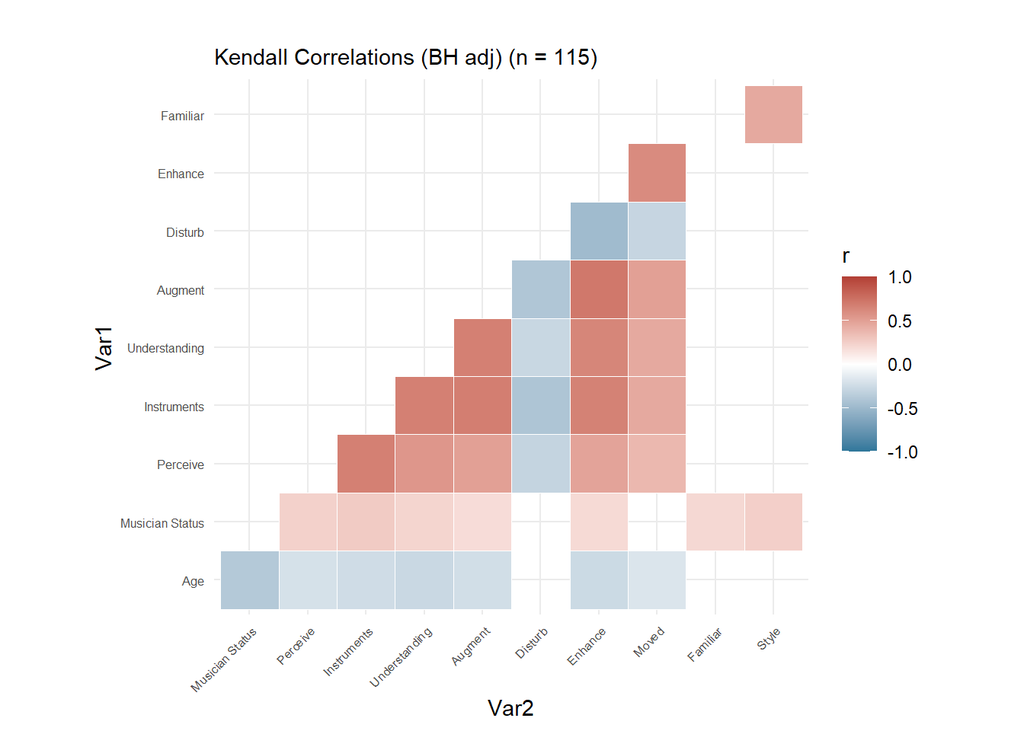

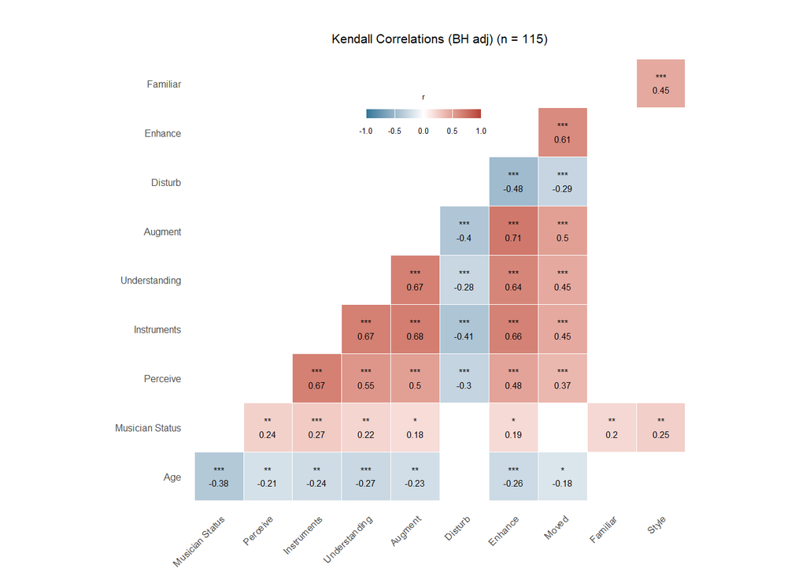

```r
cor_data_Bach<-full_data%>%select(age, musician_status, perceive_Bach:style_Bach) # note not Pt_ID, group,

#change musician_status to ranking
cor_data_Bach$musician_status<-as.numeric(cor_data_Bach$musician_status)

#select only complete
cor_data_Bach_nona<-na.omit(cor_data_Bach) # however maybe you could retain more data if you simply got rid of the age col since this seems to be what is missing most often.
names(cor_data_Bach_nona)<-c("Age", "Musician Status", "Perceive", "Instruments","Understanding", "Augment", "Disturb", "Enhance", "Moved", "Familiar","Style")

# check number of samples
samples<-nrow(cor_data_Bach_nona)
colours_DSQ<-c("#2d769a", "white","#b34036")
title = ""
#title = "Bach Visualization"
subtitle = paste0("Kendall Correlations (BH adj) (n = ", samples, ")")
chart.correlation(cor_data_Bach_nona, colours_DSQ, title, subtitle) #moved the cross-correlation code to the useful_functions script to make this more tidy.
```

```r
graphname<-paste0("../plots/Kendall-Correlations-Live_and_Online_BachVis.png")
ggsave(graphname,
       width = 10,
       height = 9,
       units = 'cm',
       dpi = 500)
```

### Online (Controlled Experiment) Only

Without the age variable

Musical sophistication: Zhang and Schubert 2019 Perceive:

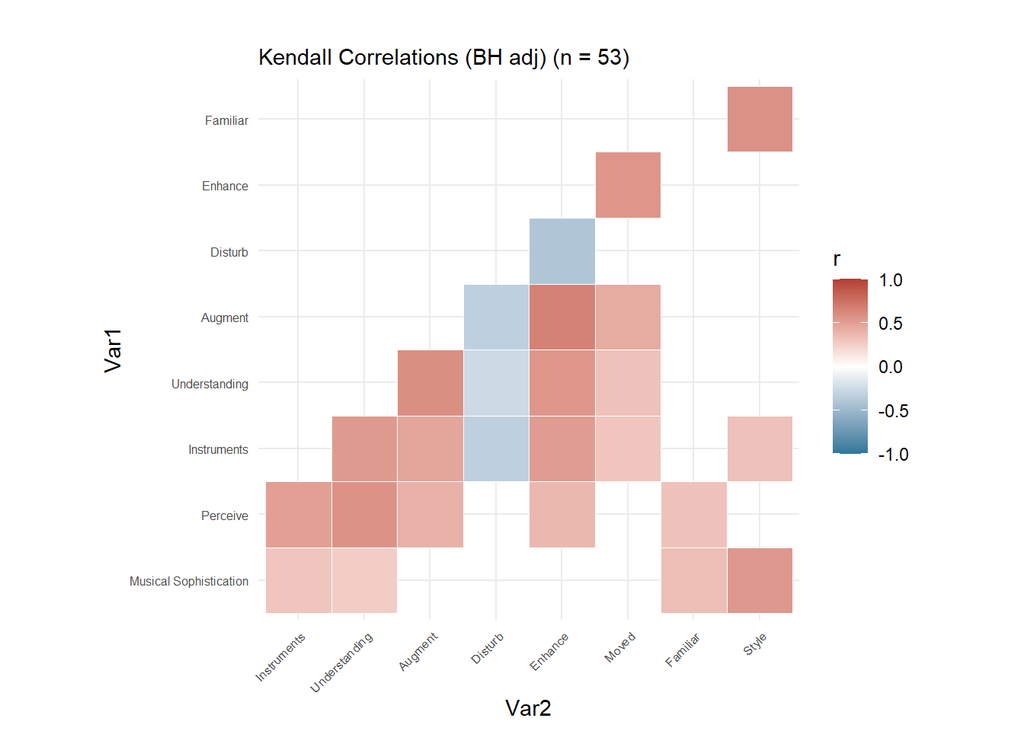

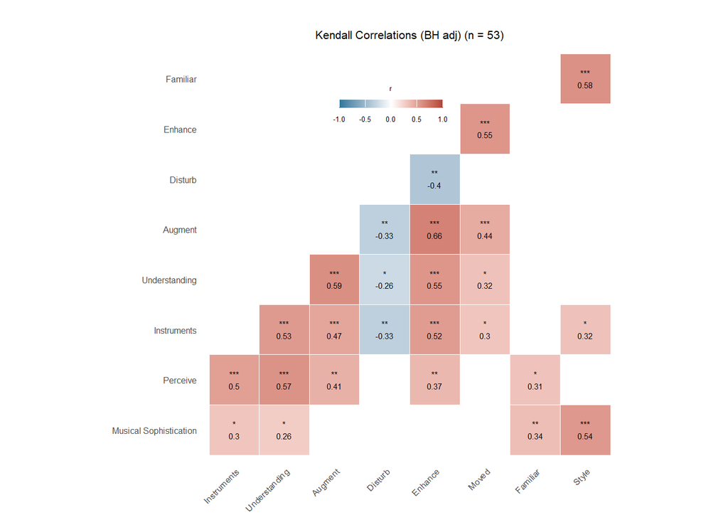

```r
cor_data_Bach<-full_data%>%filter(group == "Online")%>%select(musician_status, perceive_Bach:style_Bach) # note not Pt_ID, group, #age,

#change musician_status to ranking
cor_data_Bach$musician_status<-as.numeric(cor_data_Bach$musician_status)

#select only complete
cor_data_Bach_nona<-na.omit(cor_data_Bach) # however maybe you could retain more data if you simply got rid of the age col since this seems to be what is missing most often.
names(cor_data_Bach_nona)<-c("Musical Sophistication", "Perceive", "Instruments","Understanding", "Augment", "Disturb", "Enhance", "Moved", "Familiar","Style") # "Age",

# check number of samples
samples<-nrow(cor_data_Bach_nona)
colours_DSQ<-c("#2d769a", "white","#b34036")
title = ""
#title = "Bach Visualization"
subtitle = paste0("Kendall Correlations (BH adj) (n = ", samples, ")")
chart.correlation(cor_data_Bach_nona, colours_DSQ, title, subtitle) #moved the cross-correlation code to the useful_functions script to make this more tidy.
```

```r
graphname<-paste0("../plots/Kendall-Correlations-Online_BachVis.png")
ggsave(graphname,
       width = 10,
       height = 9,
       units = 'cm',
       dpi = 500)
```

## Reliability: Omega

### Live

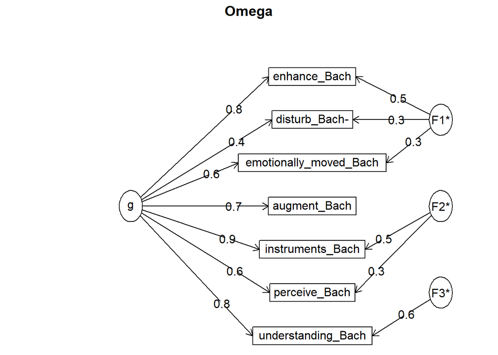

```
## Omega
## Call: omegah(m = m, nfactors = nfactors, fm = fm, key = key, flip = flip,
##     digits = digits, title = title, sl = sl, labels = labels,
##     plot = plot, n.obs = n.obs, rotate = rotate, Phi = Phi, option = option,
##     covar = covar)
## Alpha:                 0.89
## G.6:                   0.9
## Omega Hierarchical:    0.8
## Omega H asymptotic:    0.86
## Omega Total            0.93
##
## Schmid Leiman Factor loadings greater than  0.2
##                           g   F1*   F2*   F3*   h2    u2   p2
## perceive_Bach          0.63        0.30       0.48  0.52 0.81
## instruments_Bach       0.89        0.47       1.02 -0.02 0.79
## understanding_Bach     0.80              0.60 1.00  0.00 0.64
## augment_Bach           0.73  0.20             0.62  0.38 0.87
## disturb_Bach-          0.42  0.34             0.33  0.67 0.53
## enhance_Bach           0.81  0.55             0.97  0.03 0.68
## emotionally_moved_Bach 0.57  0.34             0.44  0.56 0.74
##
## With Sums of squares  of:
##    g  F1*  F2*  F3*
## 3.52 0.57 0.34 0.42
##
## general/max  6.15   max/min =   1.67
## mean percent general =  0.72    with sd =  0.12 and cv of  0.16
## Explained Common Variance of the general factor =  0.73
##
## The degrees of freedom are 3  and the fit is  0.06
## The number of observations was  91  with Chi Square =  4.94  with prob <  0.18
## The root mean square of the residuals is  0.02
## The df corrected root mean square of the residuals is  0.05
## RMSEA index =  0.084  and the 10 % confidence intervals are  0 0.213
## BIC =  -8.59
##
## Compare this with the adequacy of just a general factor and no group factors
## The degrees of freedom for just the general factor are 14  and the fit is  0.62
## The number of observations was  91  with Chi Square =  53.19  with prob <  1.8e-06
## The root mean square of the residuals is  0.09
## The df corrected root mean square of the residuals is  0.11
##
## RMSEA index =  0.175  and the 10 % confidence intervals are  0.128 0.228
## BIC =  -9.96
##
## Measures of factor score adequacy
##                                                  g  F1*  F2*  F3*
## Correlation of scores with factors            0.94 0.83 0.75 0.91
## Multiple R square of scores with factors      0.88 0.70 0.56 0.83
## Minimum correlation of factor score estimates 0.76 0.39 0.12 0.66
##
##  Total, General and Subset omega for each subset
##                                                  g  F1*  F2*  F3*
## Omega total for total scores and subscales    0.93 0.83 0.84 1.00
## Omega general for total scores and subscales  0.80 0.63 0.67 0.63
## Omega group for total scores and subscales    0.10 0.20 0.17 0.36
```

```r
visualization_items_live<-dat%>%select(-personal_chars, -familiar_Bach, -style_Bach)
omega(visualization_items_live)
```

### Online only

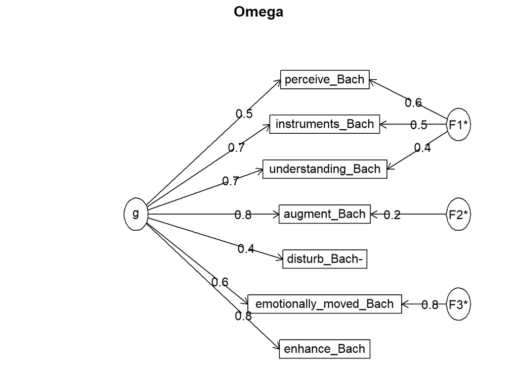

```
## Omega
## Call: omegah(m = m, nfactors = nfactors, fm = fm, key = key, flip = flip,
##     digits = digits, title = title, sl = sl, labels = labels,
##     plot = plot, n.obs = n.obs, rotate = rotate, Phi = Phi, option = option,
##     covar = covar)
## Alpha:                 0.86
## G.6:                   0.87
## Omega Hierarchical:    0.76
## Omega H asymptotic:    0.83
## Omega Total            0.91
##
## Schmid Leiman Factor loadings greater than  0.2
##                           g   F1*   F2*   F3*   h2   u2   p2
## perceive_Bach          0.51  0.58             0.60 0.40 0.44
## instruments_Bach       0.68  0.51             0.73 0.27 0.64
## understanding_Bach     0.74  0.43             0.75 0.25 0.74
## augment_Bach           0.82        0.23       0.74 0.26 0.92
## disturb_Bach-          0.39                   0.17 0.83 0.90
## enhance_Bach           0.79                   0.69 0.31 0.90
## emotionally_moved_Bach 0.56              0.82 1.00 0.00 0.32
##
## With Sums of squares  of:
##    g  F1*  F2*  F3*
## 3.05 0.78 0.12 0.72
##
## general/max  3.9   max/min =   6.78
## mean percent general =  0.69    with sd =  0.24 and cv of  0.35
## Explained Common Variance of the general factor =  0.65
##
## The degrees of freedom are 3  and the fit is  0.04
## The number of observations was  106  with Chi Square =  3.93  with prob <  0.27
## The root mean square of the residuals is  0.02
## The df corrected root mean square of the residuals is  0.05
## RMSEA index =  0.053  and the 10 % confidence intervals are  0 0.182
## BIC =  -10.06
##
## Compare this with the adequacy of just a general factor and no group factors
## The degrees of freedom for just the general factor are 14  and the fit is  0.56
## The number of observations was  106  with Chi Square =  57.06  with prob <  3.8e-07
## The root mean square of the residuals is  0.11
## The df corrected root mean square of the residuals is  0.13
##
## RMSEA index =  0.17  and the 10 % confidence intervals are  0.126 0.219
## BIC =  -8.23
##
## Measures of factor score adequacy
##                                                  g  F1*   F2*  F3*
## Correlation of scores with factors            0.90 0.75  0.33 0.96
## Multiple R square of scores with factors      0.82 0.56  0.11 0.91
## Minimum correlation of factor score estimates 0.64 0.11 -0.79 0.83
##
##  Total, General and Subset omega for each subset
##                                                  g  F1*  F2*  F3*
## Omega total for total scores and subscales    0.91 0.87 0.59 0.89
## Omega general for total scores and subscales  0.76 0.54 0.54 0.57
## Omega group for total scores and subscales    0.13 0.33 0.05 0.31
```

```r
visualization_items_online<-full_data%>%filter(group == "Online")%>%select(perceive_Bach:emotionally_moved_Bach)
omega(visualization_items_online)
```

### Live and Online

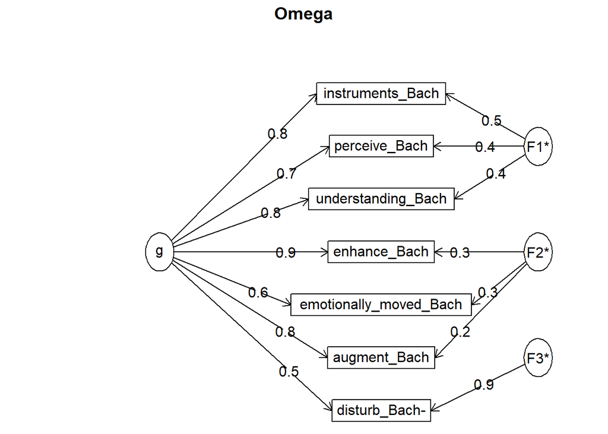

```
## Omega
## Call: omegah(m = m, nfactors = nfactors, fm = fm, key = key, flip = flip,
##     digits = digits, title = title, sl = sl, labels = labels,
##     plot = plot, n.obs = n.obs, rotate = rotate, Phi = Phi, option = option,
##     covar = covar)
## Alpha:                 0.9
## G.6:                   0.91
## Omega Hierarchical:    0.82
## Omega H asymptotic:    0.87
## Omega Total            0.95
##
## Schmid Leiman Factor loadings greater than  0.2
##                           g   F1*   F2*   F3*   h2   u2   p2
## perceive_Bach          0.66  0.41             0.61 0.39 0.72
## instruments_Bach       0.81  0.53             0.94 0.06 0.70
## understanding_Bach     0.80  0.35             0.77 0.23 0.82
## augment_Bach           0.81        0.21       0.74 0.26 0.89
## disturb_Bach-          0.47              0.88 1.00 0.00 0.22
## enhance_Bach           0.86        0.34       0.87 0.13 0.86
## emotionally_moved_Bach 0.63        0.29       0.48 0.52 0.82
##
## With Sums of squares  of:
##    g  F1*  F2*  F3*
## 3.75 0.61 0.26 0.79
##
## general/max  4.78   max/min =   2.97
## mean percent general =  0.72    with sd =  0.23 and cv of  0.32
## Explained Common Variance of the general factor =  0.69
##
## The degrees of freedom are 3  and the fit is  0.06
## The number of observations was  197  with Chi Square =  11.77  with prob <  0.0082
## The root mean square of the residuals is  0.01
## The df corrected root mean square of the residuals is  0.04
## RMSEA index =  0.122  and the 10 % confidence intervals are  0.054 0.199
## BIC =  -4.08
##
## Compare this with the adequacy of just a general factor and no group factors
## The degrees of freedom for just the general factor are 14  and the fit is  0.65
## The number of observations was  197  with Chi Square =  125.27  with prob <  5.8e-20
## The root mean square of the residuals is  0.09
## The df corrected root mean square of the residuals is  0.11
##
## RMSEA index =  0.201  and the 10 % confidence intervals are  0.17 0.234
## BIC =  51.3
##
## Measures of factor score adequacy
##                                                  g  F1*   F2*  F3*
## Correlation of scores with factors            0.92 0.76  0.54 0.98
## Multiple R square of scores with factors      0.85 0.57  0.29 0.95
## Minimum correlation of factor score estimates 0.70 0.15 -0.42 0.91
##
##  Total, General and Subset omega for each subset
##                                                  g  F1*  F2*  F3*
## Omega total for total scores and subscales    0.95 0.91 0.87 1.00
## Omega general for total scores and subscales  0.82 0.69 0.76 0.22
## Omega group for total scores and subscales    0.10 0.22 0.10 0.77
```

```r
visualization_items_all<-full_data%>%select(perceive_Bach:emotionally_moved_Bach)
omega(visualization_items_all)
```

## Factor analysis

To reduce dimensionality of the questions on the visualization so that we can then do model testing to understand the impact of musical expertise and familiarity on the experience.

### Live and Online

Redo the FA with full_data: live and online

```r
data_for_fa<-full_data%>%select(Pt_ID, perceive_Bach:emotionally_moved_Bach)
fa_dat<-data_for_fa%>%select(perceive_Bach:emotionally_moved_Bach)
```

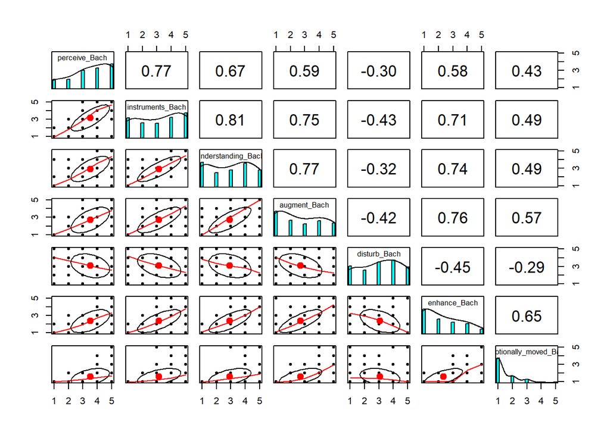

```r
pairs.panels(fa_dat)
```

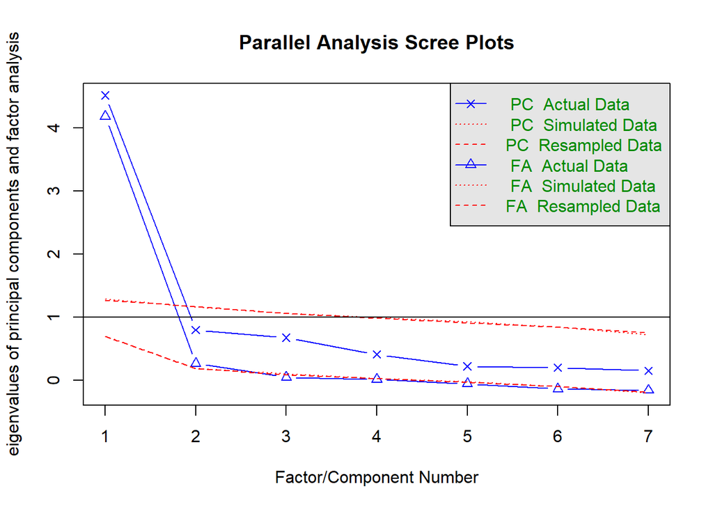

```
## Parallel analysis suggests that the number of factors =  2  and the number of components =  1
```

```r
# Test for the number of factors using parallel analysis or very simple structure
fa.parallel(fa_dat) #this suggests that there are 2 factors and 1 component
```

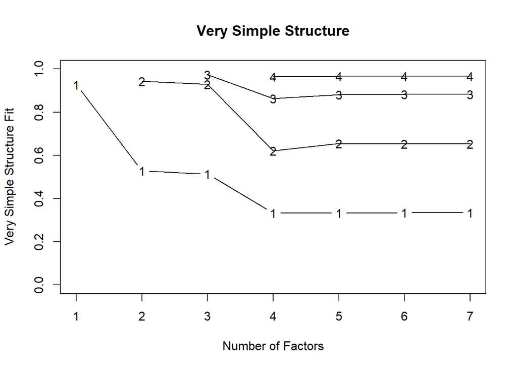

```
##
## Very Simple Structure
## Call: vss(x = fa_dat)
## VSS complexity 1 achieves a maximimum of 0.93  with  1  factors
## VSS complexity 2 achieves a maximimum of 0.94  with  2  factors
##
## The Velicer MAP achieves a minimum of 0.06  with  1  factors
## BIC achieves a minimum of  -18.57  with  2  factors
## Sample Size adjusted BIC achieves a minimum of  5.42  with  3  factors
##
## Statistics by number of factors
##   vss1 vss2  map dof   chisq    prob sqresid  fit RMSEA   BIC SABIC complex
## 1 0.93 0.00 0.06  14 8.8e+01 7.3e-13    1.56 0.93  0.16  14.5  58.9     1.0
## 2 0.53 0.94 0.14   8 2.4e+01 2.6e-03    1.22 0.94  0.10 -18.6   6.8     1.6
## 3 0.51 0.93 0.20   3 1.2e+01 8.2e-03    0.57 0.97  0.12  -4.1   5.4     1.6
## 4 0.33 0.62 0.25  -1 5.5e-01      NA    0.76 0.97    NA    NA    NA     2.3
## 5 0.33 0.65 0.49  -4 3.1e-09      NA    0.70 0.97    NA    NA    NA     2.4
## 6 0.33 0.65 1.00  -6 0.0e+00      NA    0.69 0.97    NA    NA    NA     2.4
## 7 0.33 0.65   NA  -7 0.0e+00      NA    0.69 0.97    NA    NA    NA     2.4
##    eChisq    SRMR eCRMS eBIC
## 1 2.4e+01 5.4e-02 0.066  -50
## 2 4.6e+00 2.4e-02 0.038  -38
## 3 1.8e+00 1.5e-02 0.039  -14
## 4 5.4e-02 2.6e-03    NA   NA
## 5 3.7e-10 2.1e-07    NA   NA
## 6 3.7e-16 2.1e-10    NA   NA
## 7 3.7e-16 2.1e-10    NA   NA
```

```r
vss(fa_dat) # this suggests that the complexity 1 solution achieves max at 1 factor and complexity 2 solution achieve maximum at 2 factors
```

#### One-factor Solution

```r
visualization_factor_analysis_1<-fa(fa_dat, 1)
visualization_factor_analysis_1
```

```
## Factor Analysis using method =  minres
## Call: fa(r = fa_dat, nfactors = 1)
## Standardized loadings (pattern matrix) based upon correlation matrix
##                          MR1   h2   u2 com
## perceive_Bach           0.74 0.54 0.46   1
## instruments_Bach        0.89 0.80 0.20   1
## understanding_Bach      0.87 0.75 0.25   1
## augment_Bach            0.87 0.75 0.25   1
## disturb_Bach           -0.46 0.21 0.79   1
## enhance_Bach            0.86 0.75 0.25   1
## emotionally_moved_Bach  0.62 0.39 0.61   1
##
##                 MR1
## SS loadings    4.18
## Proportion Var 0.60
##
## Mean item complexity =  1
## Test of the hypothesis that 1 factor is sufficient.
##
## df null model =  21  with the objective function =  4.92 with Chi Square =  949.18
## df of  the model are 14  and the objective function was  0.46
##
## The root mean square of the residuals (RMSR) is  0.05
## The df corrected root mean square of the residuals is  0.07
##
## The harmonic n.obs is  194 with the empirical chi square  23.43  with prob <  0.054
## The total n.obs was  197  with Likelihood Chi Square =  88.5  with prob <  7.3e-13
##
## Tucker Lewis Index of factoring reliability =  0.879
## RMSEA index =  0.164  and the 90 % confidence intervals are  0.133 0.198
## BIC =  14.53
## Fit based upon off diagonal values = 0.99
## Measures of factor score adequacy
##                                                    MR1
## Correlation of (regression) scores with factors   0.97
## Multiple R square of scores with factors          0.94
## Minimum correlation of possible factor scores     0.88
```

```r
visualization_factor_analysis_1$Vaccounted
```

```
##                      MR1
## SS loadings    4.1842606
## Proportion Var 0.5977515
```

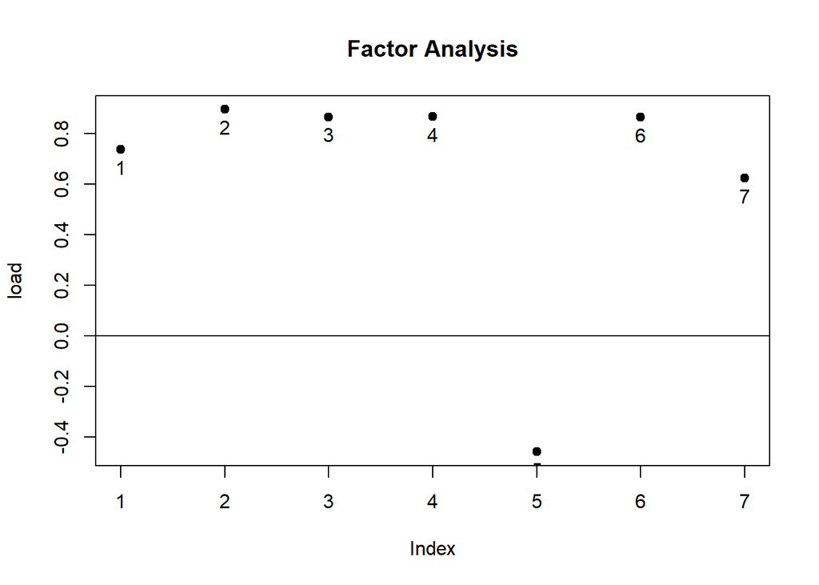

```r
plot(visualization_factor_analysis_1)
```

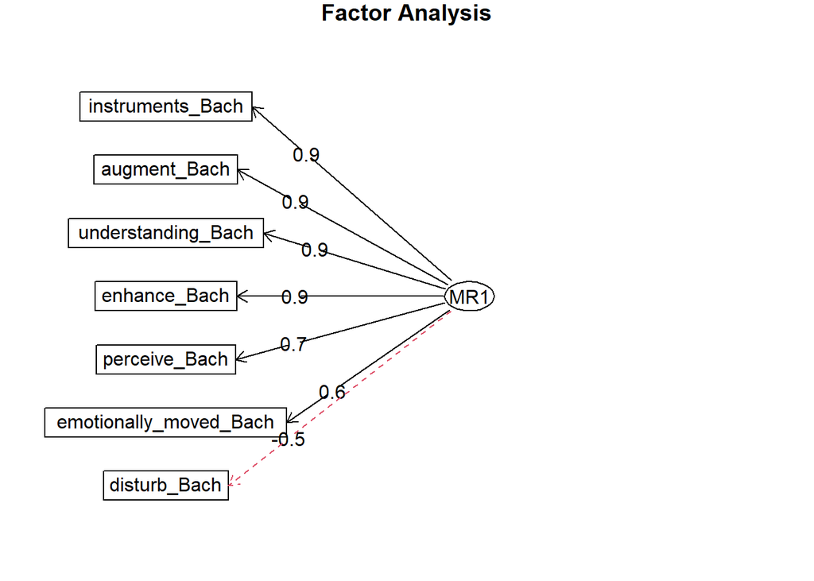

```r
fa.diagram(visualization_factor_analysis_1)
```

#### Two-factor Solution It is interesting to see its structure because now there is a factor for understanding and an emotional/enhancing factor. But the understanding and enhancing factors are highly correlated.

```r
visualization_factor_analysis_2<-fa(fa_dat, 2)
visualization_factor_analysis_2
```

```
## Factor Analysis using method =  minres
## Call: fa(r = fa_dat, nfactors = 2)
## Standardized loadings (pattern matrix) based upon correlation matrix
##                          MR1   MR2   h2    u2 com
## perceive_Bach           0.80 -0.02 0.62 0.384 1.0
## instruments_Bach        0.99 -0.03 0.94 0.062 1.0
## understanding_Bach      0.67  0.24 0.75 0.248 1.3
## augment_Bach            0.34  0.57 0.74 0.257 1.6
## disturb_Bach           -0.10 -0.38 0.22 0.783 1.1
## enhance_Bach           -0.01  0.96 0.90 0.099 1.0
## emotionally_moved_Bach -0.04  0.70 0.46 0.542 1.0
##
##                        MR1  MR2
## SS loadings           2.44 2.18
## Proportion Var        0.35 0.31
## Cumulative Var        0.35 0.66
## Proportion Explained  0.53 0.47
## Cumulative Proportion 0.53 1.00
##
##  With factor correlations of
##      MR1  MR2
## MR1 1.00 0.79
## MR2 0.79 1.00
##
## Mean item complexity =  1.1
## Test of the hypothesis that 2 factors are sufficient.
##
## df null model =  21  with the objective function =  4.92 with Chi Square =  949.18
## df of  the model are 8  and the objective function was  0.12
##
## The root mean square of the residuals (RMSR) is  0.02
## The df corrected root mean square of the residuals is  0.04
##
## The harmonic n.obs is  194 with the empirical chi square  4.55  with prob <  0.8
## The total n.obs was  197  with Likelihood Chi Square =  23.7  with prob <  0.0026
##
## Tucker Lewis Index of factoring reliability =  0.955
## RMSEA index =  0.1  and the 90 % confidence intervals are  0.055 0.148
## BIC =  -18.57
## Fit based upon off diagonal values = 1
## Measures of factor score adequacy
##                                                    MR1  MR2
## Correlation of (regression) scores with factors   0.98 0.97
## Multiple R square of scores with factors          0.96 0.94
## Minimum correlation of possible factor scores     0.92 0.87
```

```r
visualization_factor_analysis_2$Vaccounted
```

```
##                             MR1       MR2
## SS loadings           2.4413201 2.1844144
## Proportion Var        0.3487600 0.3120592
## Cumulative Var        0.3487600 0.6608192
## Proportion Explained  0.5277692 0.4722308
## Cumulative Proportion 0.5277692 1.0000000
```

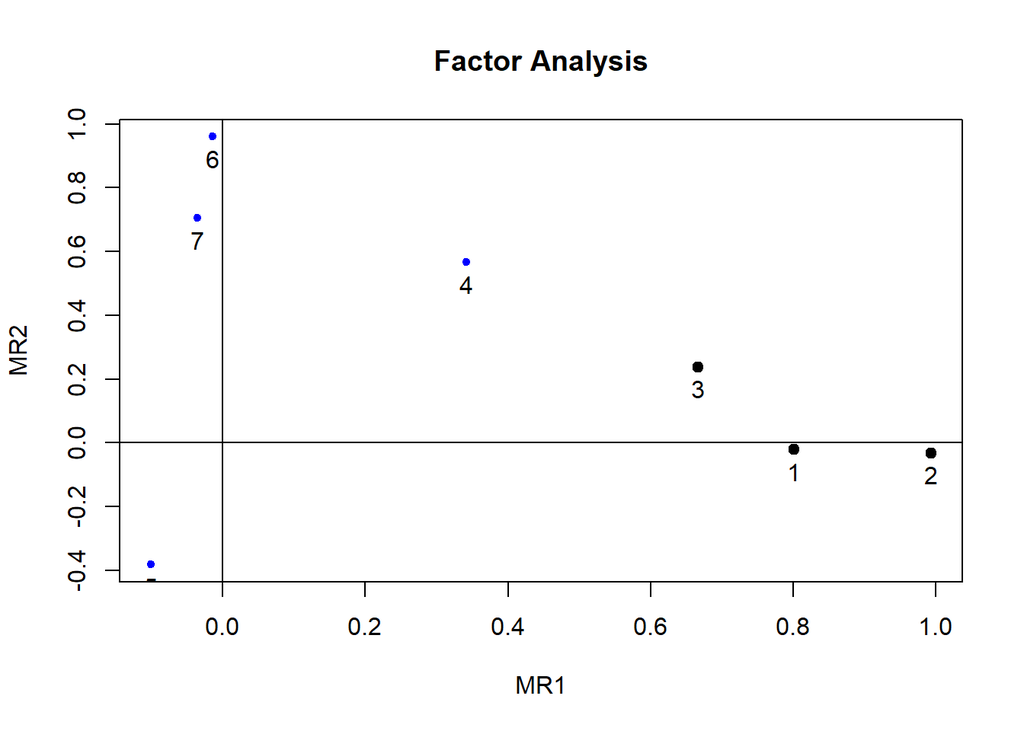

```r
plot(visualization_factor_analysis_2)
```

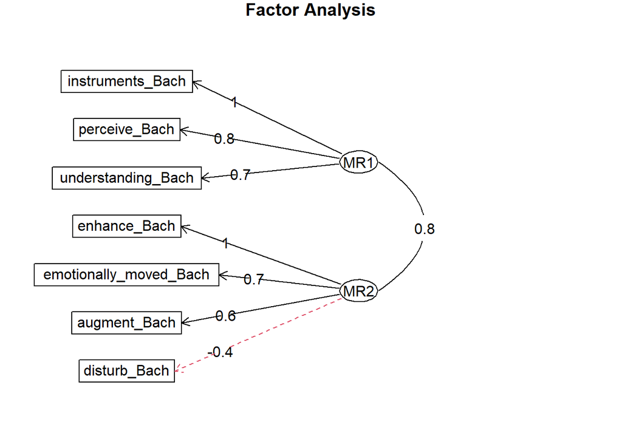

```r
fa.diagram(visualization_factor_analysis_2)
```

March 3rd, 2025: Compute metrics for assessing whether the dataset is appropriate for factor analysis as recommended by the reviewer.

Bartlett’s test of sphericity and the Kaiser-Meyer-Olkin

```r
library(performance)
check_factorstructure(fa_dat)
```

```
## # Is the data suitable for Factor Analysis?
##
##
##   - Sphericity: Bartlett's test of sphericity suggests that there is sufficient significant correlation in the data for factor analysis (Chisq(21) = 949.18, p < .001).
##   - KMO: The Kaiser, Meyer, Olkin (KMO) overall measure of sampling adequacy suggests that data seems appropriate for factor analysis (KMO = 0.88). The individual KMO scores are: perceive_Bach (0.88), instruments_Bach (0.85), understanding_Bach (0.88), augment_Bach (0.91), disturb_Bach (0.86), en…
```

#### Add 2FA factor scores to df

```r
visualization_factor_analysis_2_scores<-psych::factor.scores(fa_dat, visualization_factor_analysis_2)

visualization_factors<-cbind(data_for_fa$Pt_ID,data.frame(visualization_factor_analysis_2_scores$scores))

colnames(visualization_factors)<- c("Pt_ID","Grasp","Appreciate")

cbind(visualization_factors$Pt_ID, full_data$Pt_ID)
```

```
##        [,1]     [,2]
##   [1,] "AEQ086" "AEQ086"
##   [2,] "AEU091" "AEU091"
##   [3,] "AEQ088" "AEQ088"
##   [4,] "AEQ077" "AEQ077"
##   [5,] "AEQ081" "AEQ081"
##   [6,] "AEQ079" "AEQ079"
##   [7,] "AEQ084" "AEQ084"
##   [8,] "AER090" "AER090"
##   [9,] "AEQ082" "AEQ082"
##  [10,] "AEQ089" "AEQ089"
##  [11,] "AEQ080" "AEQ080"
##  [12,] "AEQ083" "AEQ083"
##  [13,] "AEQ087" "AEQ087"
##  [14,] "AEQ078" "AEQ078"
```

[output cut: 183 more lines]

```r
full_data<-cbind(full_data,visualization_factors[2:3])
```